# R MarkDown example

First of all, I learned a lot about the customisation from the [R Markdown Cookbook](https://bookdown.org/yihui/rmarkdown-cookbook/).

## Start of the project

Start to load a library. Most of the time it is a good habit to keep the warning and other messages at this step, *eg* to know which function was masked from another package. But here I want to show that it is possible to have a clean output.

```r
library(tidyverse)

set.seed <- 654136136
```

## Import data

As said in the title, import the data. The code-block is hidden by default thanks to the tag `class.source = 'fold-hide'`.

```r
attach(iris)
```

## A plot

### Few words

Let’s plot the data. Because I do not want a large plot, I can set the width and height of the figure, and center it. See sections *5.4* and *5.5* of the *R Markdown Cookbook* for more details and options.

### The figure

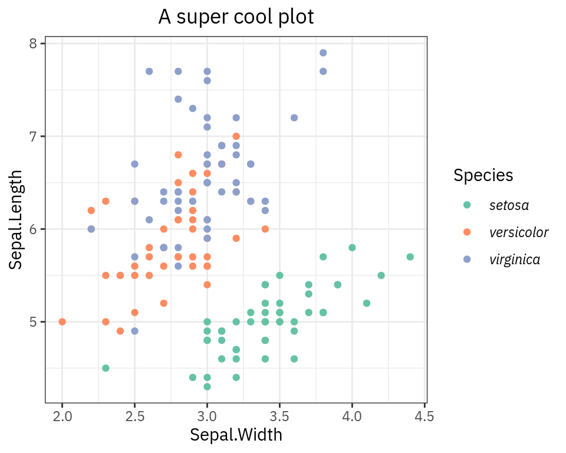

```r
ggplot(iris, aes(x = Sepal.Width, y = Sepal.Length, colour = Species)) +
  geom_point() +
  scale_colour_brewer(palette = "Set2") +
  labs(title = "A super cool plot") +
  theme_bw() +
  theme(text = element_text(family = "IBM Plex Sans"),
        legend.text = element_text(face = "italic"),
        plot.title = element_text(hjust = 0.5) )
```

## Code-block not rendered

The code-block below is not ran during the rendering ( *“Knitting”* ) of the document. This can be interesting when you saved a figure in a file (`svg`, `png` or the format you like, which must be `svg`). Because you did some edits, it is not a desirable to generate again the file and erase your work…  
This is also applicable for tables, object saved as `MyObject.RDS` and so on.

```r
# This file is not generated during rendering because the chunk is not ran
ggsave("my_test_figure.svg", width = 5, height = 4, dppi = 300)
```

## Show a table

It is possible to display tables nicely. Here are the first 6 lines from the *iris* data set. There is a complete section in the *R Markdown cookbook*, [section *10*](https://bookdown.org/yihui/rmarkdown-cookbook/tables.html).

```r
knitr::kable(head(iris),
             caption = "Overview of the iris dataset", align = "c")
```

Overview of the iris dataset

| Sepal.Length | Sepal.Width | Petal.Length | Petal.Width | Species |
| --- | --- | --- | --- | --- |
| 5.1 | 3.5 | 1.4 | 0.2 | setosa |
| 4.9 | 3.0 | 1.4 | 0.2 | setosa |
| 4.7 | 3.2 | 1.3 | 0.2 | setosa |
| 4.6 | 3.1 | 1.5 | 0.2 | setosa |
| 5.0 | 3.6 | 1.4 | 0.2 | setosa |
| 5.4 | 3.9 | 1.7 | 0.4 | setosa |

It is not perfect, there is something better to do with the `kableExtra` library.

## Future advices

*WIP*